# Estrutura hiperfina do átomo de Hidrogênio

Como vimos, a interação eletrostática entre as cargas elétricas do próton e do elétron no átomo de Hidrogênio dá origem a sua estrutura "principal" de níveis energia: \begin{equation} \text{estrutura principal}\propto 1\text{ eV}. \end{equation} No entanto, também vimos que a interação entre o momento magnético do elétron com o campo magnético gerado pelo movimento relativo do próton, a consideração de efeitos relativísticos do movimento do elétron e a consideração de que o elétron, sendo um sistema quântico, tem dimensão espacial finita, nos levam à identificação de uma estrutura fina para os níveis de energia do átomo de Hidrogênio: \begin{equation} \text{estrutura fina}\propto 10^{-3}\text{ eV}. \end{equation} Na sequência, consideraremos a interação do spin do elétron com o campo magnético gerado pelo spin do próton (ou vice-versa). Essa interação dará origem a correções ainda menores para a energia de $H$, sendo responsável pela chamada estrutura hiperfina do átomo de Hidrogênio: \begin{equation} \text{estrutura hiperfina}\propto 10^{-6}\text{ eV}. \end{equation}

A seguir vamos iniciar obtendo o campo magnético gerado por um momento de dipolo magnético clássico. Usaremos esse campo para obter a energia potencial de interação entre dois momentos de dipolo magnético clássicos. Feito isso, quantizaremos essa expressão para obter o hamiltoniano que descreve a interação entre dois dipolos magnéticos quânticos. Esse hamiltoniano será usado para obter as correções perturbativas que levam a estrutura hiperfina de $H$.

OBS. Todas esses resultados se aplicam também para átomos hidrogenóides.

## Campo magnético gerado por um dipolo magnético

Começamos considerando o potencial vetor magnético \begin{equation} \vec{\mathcal{A}} = \frac{\mu_{0}}{4\pi}\int_{V'}\frac{\vec{J}(\vec{r}')}{||\vec{r}-\vec{r}'||}dV', \end{equation} em que $\vec{r}$ é a posição do ponto $P$ onde estamos calculando $\vec{\mathcal{A}}$ e $\vec{r}'$ é a posição da densidade de corrente elétrica $\vec{J}$ em relação ao centro da distribuição de correntes. Usando a série de Taylor \begin{equation} (1+x)^{-1/2}=1-0.5x+\cdots, \end{equation} podemos escrever \begin{align} \frac{1}{||\vec{r}-\vec{r}'||} & = \frac{1}{\sqrt{r^{2}+r'^{2}-2\vec{r}\cdot\vec{r}'}} = \frac{1}{r\sqrt{1+r'^{2}/r^{2}-2\vec{r}\cdot\vec{r}'/r^{2}}} \\ & = \frac{1}{r}\left(1+\frac{r'^{2}}{r^{2}}-2\frac{\vec{r}\cdot\vec{r}'}{r^{2}}\right)^{-1/2} \approx \frac{1}{r}\left(1-\frac{1}{2}\frac{r'^{2}}{r^{2}}+\frac{1}{2}2\frac{\vec{r}\cdot\vec{r}'}{r^{2}}\right) \\ & = \frac{1}{r}-\frac{1}{2}\frac{r'^{2}}{r^{3}} + \frac{\vec{r}\cdot\vec{r}'}{r^{3}} \approx \frac{1}{r} + \frac{\vec{r}\cdot\vec{r}'}{r^{3}}. \end{align} Na última passagem, desprezamos o 2º termo considerando um dipolo magnético de dimensão muito pequena, i.e., $r'\ll r$.

```python
%run init.ipynb
x = symbols('x'); series((1+x)**(-1/2), x, 0, 5)
```

$\displaystyle 1 - 0.5 x + 0.375 x^{2} - 0.3125 x^{3} + 0.2734375 x^{4} + O\left(x^{5}\right)$

Com isso, teremos que \begin{align} \vec{\mathcal{A}} & = \frac{\mu_{0}}{4\pi}\int_{V'}\frac{\vec{J}}{r}dV' + \frac{\mu_{0}}{4\pi}\int_{V'}\frac{(\vec{r}\cdot\vec{r}')\vec{J}}{r^{3}}dV' \\ & = \frac{\mu_{0}}{4\pi r}\int_{V'}\vec{J}dV' + \frac{\mu_{0}}{4\pi r^{3}}\int_{V'}(\vec{r}\cdot\vec{r}')\vec{J}dV' \end{align} Usando \begin{equation} \vec{\nabla}\cdot\big(\phi\vec{A}\big) = \vec{\nabla}\phi\cdot\vec{A} + \phi\vec{\nabla}\cdot\vec{A}, \end{equation} que vale para $\phi(\vec{r})$ um campo escalar qualquer e para $\vec{A}(\vec{r})$ um campo vetorial qualquer, pode-se demonstrar que \begin{equation} \int_{V}\big(f\vec{J}\cdot\vec{\nabla}g+g\vec{J}\cdot\vec{\nabla}f\big)dV = 0, \hspace{1cm} (\star) \end{equation} em que $f(\vec{r})$ e $g(\vec{r})$ são funções bem comportadas e $\vec{J}$ é uma distribuição de corrente elétrica estacionária e localizada em um volume finito.

Se escolhemos \begin{equation} f(\vec{r}) = 1 \text{ e } g(\vec{r})=x_{j}, \end{equation} e as substituímos na eq. ($\star$), vem que \begin{align} & \int_{V}\big(1\vec{J}\cdot\vec{\nabla}x_{j}+x_{j}\vec{J}\cdot\vec{\nabla}1\big)dV = \int_{V}\big(\vec{J}\cdot\hat{e}_{j}+0\big)dV \\ & = \int_{V}J_{j}dV = 0, \end{align} que implica que \begin{equation} \int_{V}\vec{J}dV = \sum_{j}\hat{e}_{j}\int_{V}J_{j}dV = \vec{0}. \end{equation}

Seguindo, substituindo esse resultado na equação para o potencial vetor magnético, e usando \begin{equation} \vec{A}\cdot\int_{V}\vec{r}J_{i}dV = -\frac{1}{2}\sum_{j,k}\epsilon_{ijk}A_{j}\int_{V}\big(\vec{r}\times\vec{J}\big)_{k}dV, \end{equation} que é válida para qualquer campo vetorial $\vec{A}$, teremos \begin{align} \vec{\mathcal{A}} & = 0 + \frac{\mu_{0}}{4\pi r^{3}}\int_{V'}(\vec{r}\cdot\vec{r}')\vec{J}dV' = \sum_{i}\hat{e}_{i}\frac{\mu_{0}}{4\pi r^{3}}\vec{r}\cdot\int_{V'}\vec{r}'J_{i}dV' \\ & = -\sum_{ijk}\epsilon_{ijk}\hat{e}_{i}\frac{\mu_{0}}{4\pi r^{3}}x_{j}\frac{1}{2}\int_{V'}\big(\vec{r}'\times\vec{J}\big)_{k}dV' = \sum_{i}\hat{e}_{i}\Big(-\frac{\mu_{0}}{4\pi r^{3}}\sum_{jk}\epsilon_{ijk}x_{j}\mu_{k}\Big) \\ & = -\frac{\mu_{0}}{4\pi r^{3}}\sum_{i}\hat{e}_{i}(\vec{r}\times\vec{\mu})_{i} = -\frac{\mu_{0}}{4\pi r^{3}}\vec{r}\times\vec{\mu}, \end{align} em que usamos a definição de **momento de dipolo magnético**: \begin{equation} \vec{\mu} := \frac{1}{2}\int_{V'}\vec{r}'\times\vec{J}dV'. \end{equation}

Utilizando a igualdade \begin{equation} \vec{\nabla}\times(\vec{A}\times\vec{B}) = (\vec{\nabla}\cdot\vec{B})\vec{A} - (\vec{\nabla}\cdot\vec{A})\vec{B} + (\vec{B}\cdot\vec{\nabla})\vec{A} - (\vec{A}\cdot\vec{\nabla})\vec{B} \end{equation} vamos passar para o cálculo do **campo magnético** gerado pelo dipolo magnético: \begin{align} \vec{B} & = \vec{\nabla}\times\vec{\mathcal{A}} = -\frac{\mu_{0}}{4\pi}\vec{\nabla}\times\Big(\frac{\vec{r}}{r^{3}}\times\vec{\mu}\Big) \\ & = -\frac{\mu_{0}}{4\pi}\Big((\vec{\nabla}\cdot\vec{\mu})\frac{\vec{r}}{r^{3}} -\Big(\vec{\nabla}\cdot\frac{\vec{r}}{r^{3}}\Big)\vec{\mu} +(\vec{\mu}\cdot\vec{\nabla})\frac{\vec{r}}{r^{3}} -\Big(\frac{\vec{r}}{r^{3}}\cdot\vec{\nabla}\Big)\vec{\mu}\Big) \\ & = \frac{\mu_{0}}{4\pi}\Big(\Big(\vec{\nabla}\cdot\frac{\vec{r}}{r^{3}}\Big)\vec{\mu} -(\vec{\mu}\cdot\vec{\nabla})\frac{\vec{r}}{r^{3}}\Big), \end{align} em que usamos \begin{equation} \vec{\nabla}\cdot\vec{\mu} = \Big(\frac{\vec{r}}{r^{3}}\cdot\vec{\nabla}\Big)\vec{\mu} = 0 \end{equation} pois o momento de dipolo magnético é um vetor fixo no espaço.

Pode-se verificar que \begin{equation} \vec{\nabla}\cdot\frac{\vec{r}}{r^{3}} = 4\pi\delta(\vec{r}). \end{equation} e que \begin{equation} (\vec{\mu}\cdot\vec{\nabla})\frac{\vec{r}}{r^{3}} = \frac{\vec{\mu}}{r^{3}} - 3\frac{(\vec{\mu}\cdot\vec{r})\vec{r}}{r^{5}}. \end{equation}

Substituindo esses resultados, podemos escrever o campo magnético como segue \begin{align} \vec{B} & = \frac{\mu_{0}}{4\pi}\Big(4\pi\delta(\vec{r})\vec{\mu} - \frac{\vec{\mu}}{r^{3}} + \frac{3(\vec{\mu}\cdot\vec{r})\vec{r}}{r^{5}}\Big) \\ & = \frac{\mu_{0}}{4\pi}\Big(\frac{3(\vec{\mu}\cdot\hat{r})\hat{r} - \vec{\mu}}{r^{3}} + 4\pi(1-d)\delta(\vec{r})\vec{\mu} \Big), \end{align} onde introduzimos o parâmetro $d$, chamado de *fator de desmagnetização*, que é usado de maneira fenomenológica para levar em conta possíveis assimetrias da distribuição de correntes responsável pelo dipolo magnético.

Com isso, podemos calcular a energia potencial de interação entre o momento magnético do elétron com o campo magnético gerado pelo momento magnético do próton: \begin{align} U & = -\vec{\mu}_{e}\cdot\vec{B} \\ & = -\vec{\mu}_{e}\cdot\frac{\mu_{0}}{4\pi}\Big(\frac{3(\vec{\mu}_{p}\cdot\hat{r})\hat{r} - \vec{\mu}_{p}}{r^{3}} + 4\pi(1-d)\delta(\vec{r})\vec{\mu}_{p} \Big) \\ & = \frac{\mu_{0}}{4\pi}\Big(\frac{\vec{\mu}_{e}\cdot\vec{\mu}_{p} - 3(\vec{\mu}_{p}\cdot\hat{r})(\vec{\mu}_{e}\cdot\hat{r})}{r^{3}} - 4\pi(1-d)\delta(\vec{r})\vec{\mu}_{e}\cdot\vec{\mu}_{p}\Big). \end{align}

Usando a relação entre momento magnético e momento angular para uma carga elétrica $q$ em movimento circular, \begin{equation} \vec{\mu} = \frac{q}{2m}\vec{L} = \frac{1}{\hbar}\frac{q\hbar}{2m}\vec{L} = \frac{1}{\hbar}\mu_{b}\vec{L}, \end{equation} com \begin{equation} \mu_{b} := \frac{q\hbar}{2m} \end{equation} sendo o magneton de Bohr, podemos escrever as relações entre os momentos de dipolo magnético intrínsecos e momentos angulares intrínsecos do elétron e do próton como segue: \begin{equation} \vec{\mu}_{e} = \frac{g_{e}\mu_{be}}{\hbar}\vec{S}_{e} \text{ e } \vec{\mu}_{p} = \frac{g_{p}\mu_{bp}}{\hbar}\vec{S}_{p}, \end{equation} em que introduzimos os fatores giromagnéticos do elétron e do próton e usamos \begin{equation} \mu_{be} = \frac{-e\hbar}{2m_{e}} \text{ e } \mu_{bp} = \frac{e\hbar}{2m_{p}}. \end{equation}

Com isso podemos substituir as variáveis clássicas na expressão para a energia potencial de interação entre os dois momentos de dipolo magnético para assim obter o operador hamiltoniano quântico: \begin{equation} H_{1}^{ss} = \frac{\mu_{0}g_{e}\mu_{be}g_{p}\mu_{bp}}{4\pi\hbar^{2}}\Big(\frac{\vec{S}_{e}\cdot\vec{S}_{p} - 3(\vec{S}_{p}\cdot\hat{r})(\vec{S}_{e}\cdot\hat{r})}{r^{3}} - 4\pi(1-d)\delta(\vec{r})\vec{S}_{e}\cdot\vec{S}_{p}\Big). \end{equation}

Seguindo, utilizaremos a soma de momentos angulares de spin do próton e do elétron, \begin{equation} \vec{S} = \vec{S}_{e}\otimes\mathbb{I}_{p} + \mathbb{I}_{e}\otimes\vec{S}_{p}, \end{equation} para escrever \begin{align} S^{2} & = \vec{S}\cdot\vec{S} = \big(\vec{S}_{e}\otimes\mathbb{I}_{p} + \mathbb{I}_{e}\otimes\vec{S}_{p}\big)\cdot\big(\vec{S}_{e}\otimes\mathbb{I}_{p} + \mathbb{I}_{e}\otimes\vec{S}_{p}\big) \\ & = \vec{S}_{e}\cdot\vec{S}_{e}\otimes\mathbb{I}_{p} + \mathbb{I}_{e}\otimes\vec{S}_{p}\cdot\vec{S}_{p} + \big(\vec{S}_{e}\otimes\mathbb{I}_{p}\big)\cdot\big(\mathbb{I}_{e}\otimes\vec{S}_{p}\big) + \big(\mathbb{I}_{e}\otimes\vec{S}_{p}\big)\cdot\big(\vec{S}_{e}\otimes\mathbb{I}_{p}\big) \\ & =: S_{e}^{2}\otimes\mathbb{I}_{p} + \mathbb{I}_{e}\otimes S_{p}^{2} + 2\vec{S}_{e}\cdot \vec{S}_{p}, \end{align} em que utilizamos a notação \begin{equation} 2\vec{S}_{e}\cdot \vec{S}_{p} := \big(\vec{S}_{e}\otimes\mathbb{I}_{p}\big)\cdot\big(\mathbb{I}_{e}\otimes\vec{S}_{p}\big) + \big(\mathbb{I}_{e}\otimes\vec{S}_{p}\big)\cdot\big(\vec{S}_{e}\otimes\mathbb{I}_{p}\big). \end{equation} Com isso, temos que \begin{equation} \vec{S}_{e}\cdot \vec{S}_{p} = \frac{1}{2}\Big(S^{2} - S_{e}^{2}\otimes\mathbb{I}_{p} - \mathbb{I}_{e}\otimes S_{p}^{2}\Big). \end{equation}

Também podemos usar \begin{align} \big(\vec{S}\cdot\vec{r}\big)^{2} & = \big((\vec{S}_{e}+\vec{S}_{p})\cdot\vec{r}\big)^{2} = \big(\vec{S}_{e}\cdot\vec{r}+\vec{S}_{p}\cdot\vec{r}\big)^{2} \\ & = (\vec{S}_{e}\cdot\vec{r})^{2} + (\vec{S}_{p}\cdot\vec{r})^{2} + 2(\vec{S}_{e}\cdot\vec{r})(\vec{S}_{p}\cdot\vec{r}) \end{align} para escrever \begin{equation} (\vec{S}_{e}\cdot\vec{r})(\vec{S}_{p}\cdot\vec{r}) = \frac{1}{2}\Big(\big(\vec{S}\cdot\vec{r}\big)^{2} -(\vec{S}_{e}\cdot\vec{r})^{2} - (\vec{S}_{p}\cdot\vec{r})^{2} \Big). \end{equation}

Com isso, podemos escrever o hamiltoniano de interação spin-spin como segue \begin{align} H_{1}^{ss} & = \frac{\mu_{0}g_{e}\mu_{be}g_{p}\mu_{bp}}{8\pi\hbar^{2}}\Big(\frac{\big(S^{2} - S_{e}^{2}\otimes\mathbb{I}_{p} - \mathbb{I}_{e}\otimes S_{p}^{2}\big) - 3\big(\big(\vec{S}\cdot\hat{r}\big)^{2} -(\vec{S}_{e}\cdot\hat{r})^{2} - (\vec{S}_{p}\cdot\hat{r})^{2} \big)}{r^{3}} \\ & \hspace{3.5cm} - 4\pi(1-d)\delta(\vec{r})\big(S^{2} - S_{e}^{2}\otimes\mathbb{I}_{p} - \mathbb{I}_{e}\otimes S_{p}^{2}\big)\Big). \end{align}

A função de onda total desse sistema deve levar em conta o grau de liberdade espacial e de spin do elétron e o grau de liberdade de spin do próton: \begin{equation} |\Psi\rangle = |\psi\rangle\otimes|\sigma_{e}\rangle\otimes|\sigma_{p}\rangle. \end{equation} Quanto aos spins, vamos trabalhar na base de autovetores comuns a $S_{e}^{2}, S_{p}^{2},S^{2}$, que é \begin{equation} |s_{e},s_{p},s,m_{s}\rangle = |1/2,1/2,s,m_{s}\rangle, \end{equation} em que usamos o fato de que os elétron e o próton são férmions com spin $1/2$: \begin{equation} s_{e} = \frac{1}{2} \text{ e } s_{p} = \frac{1}{2}. \end{equation} Da teoria sobre a soma de momentos angulares, temos que \begin{equation} s = |s_{e}-s_{p}|,|s_{e}-s_{p}|,\cdots,s_{e}+s_{p} = 0,1 \end{equation} e para cada valor do número quântico do momento angular totoal, $s$, o número quântico que determina a componente $z$ do momento angular total pode assumir os valores \begin{equation} m_{s} = -s,-s+1,\cdots,s. \end{equation} Nesse caso \begin{equation} m_{s=0}=0 \text{ e } m_{s=1} = -1,0,1. \end{equation}

Como os momentos angulares intrínsecos individuais do elétron e do próton podem ser escritos em termos das matrizes de Pauli, i.e., \begin{equation} \vec{S}_{e} = \frac{\hbar}{2}\vec{\sigma} \text{ e } \vec{S}_{p} = \frac{\hbar}{2}\vec{\sigma}. \end{equation} Com isso, vemos que \begin{align} \big(\vec{S}_{e}\cdot\hat{r}\big)^{2} & = \big(2^{-1}\hbar\vec{\sigma}\cdot\hat{r}\big)^{2} = 2^{-2}\hbar^{2}\big(\vec{\sigma}\cdot\hat{r}\big)^{2} = 2^{-2}\hbar^{2}\mathbb{I}_{e}, \\ \big(\vec{S}_{p}\cdot\hat{r}\big)^{2} & = \big(2^{-1}\hbar\vec{\sigma}\cdot\hat{r}\big)^{2} = 2^{-2}\hbar^{2}\big(\vec{\sigma}\cdot\hat{r}\big)^{2} = 2^{-2}\hbar^{2}\mathbb{I}_{p}. \end{align}

Assim, usando \begin{equation} S_{e,p}^{2}|1/2,1/2,s,m_{s}\rangle = \hbar^{2}(1/2)(1/2+1)|1/2,1/2,s,m_{s}\rangle = \hbar^{2}(3/4)|1/2,1/2,s,m_{s}\rangle, \end{equation} a correção perturbativa de primeira ordem para a energia do átomo de Hidrogênio devido à interação spin-spin pode ser escrita como: \begin{align} E_{n,l}^{ss(1)} & = \big(\big(\langle\psi|\otimes\langle1/2,1/2,s,m_{s}|\big)\big)H_{1}^{ss}\big(|\psi\rangle\otimes|1/2,1/2,s,m_{s}\rangle\big) \\ & = \frac{\mu_{0}g_{e}\mu_{be}g_{p}\mu_{bp}}{8\pi\hbar^{2}}\Big(\big(\langle\psi|\otimes\langle1/2,1/2,s,m_{s}|\big)r^{-3}\big(S^{2} - S_{e}^{2}\otimes\mathbb{I}_{p} - \mathbb{I}_{e}\otimes S_{p}^{2}\big)\big(|\psi\rangle\otimes|1/2,1/2,s,m_{s}\rangle\big) \\ & \hspace{3.5cm} - 3\big(\langle\psi|\otimes\langle1/2,1/2,s,m_{s}|\big)r^{-3}\big(\big(\vec{S}\cdot\hat{r}\big)^{2} -22^{-2}\hbar^{2}\mathbb{I}_{e}\otimes\mathbb{I}_{p} \big)\big(|\psi\rangle\otimes|1/2,1/2,s,m_{s}\rangle\big) \\ & \hspace{3.5cm} - 4\pi(1-d)\big(\langle\psi|\otimes\langle1/2,1/2,s,m_{s}|\big)\delta(\vec{r})\big(S^{2} - S_{e}^{2}\otimes\mathbb{I}_{p} - \mathbb{I}_{e}\otimes S_{p}^{2}\big)\big(|\psi\rangle\otimes|1/2,1/2,s,m_{s}\rangle\big)\Big) \\ & = \frac{\mu_{0}g_{e}\mu_{be}g_{p}\mu_{bp}}{8\pi\hbar^{2}}\Big(\big(\langle\psi|\otimes\langle1/2,1/2,s,m_{s}|\big)r^{-3}\big(S^{2} - (3\hbar^{2}/2)\big)\big(|\psi\rangle\otimes|1/2,1/2,s,m_{s}\rangle\big) \\ & \hspace{3.5cm} - 3\big(\langle\psi|\otimes\langle1/2,1/2,s,m_{s}|\big)r^{-3}\big(\big(\vec{S}\cdot\hat{r}\big)^{2} -(\hbar^{2}/2)\big)\big(|\psi\rangle\otimes|1/2,1/2,s,m_{s}\rangle\big) \\ & \hspace{3.5cm} - 4\pi(1-d)\big(\langle\psi|\otimes\langle1/2,1/2,s,m_{s}|\big)\delta(\vec{r})\big(S^{2} - (3\hbar^{2}/2)\big)\big(|\psi\rangle\otimes|1/2,1/2,s,m_{s}\rangle\big)\Big). \end{align}

Doravante vamos considerar somente autoestados do hamiltoniano não perturbado com momento angular nulo, i.e., \begin{equation} l=0. \end{equation} Com isso, além de simplificar as contas, anulamos a contribuição da interação do spin do próton com o momento magnético orbital do elétron. Nesse caso, a função de onda é dada por \begin{align} & \psi_{n,l,m_{l}}(r,\theta,\phi) = \sqrt{\left(\frac{2Z}{a_{0}n}\right)^{3}\frac{(n-l-1)!}{(n+l)!2n}}e^{-Zr/a_{0}n}\left(\frac{2Zr}{a_{0}n}\right)^{l}L_{n-l-1}^{2l+1}\left(\frac{2Zr}{a_{0}n}\right)\sqrt{\frac{2l+1}{4\pi}\frac{(l-|m_{l}|)!}{(l+|m_{l}|)!}}(\sin\theta)^{|m_{l}|}\frac{\partial^{|m_{l}|}P_{l}(\cos\theta)}{\partial z^{|m_{l}|}}e^{im_{l}\phi}, \\ & \therefore\ \psi_{n,0,0}(r,\theta,\phi) = \sqrt{\left(\frac{2Z}{a_{0}n}\right)^{3}\frac{1}{2n^{2}}}e^{-Zr/a_{0}n}L_{n-1}^{1}\left(\frac{2Zr}{a_{0}n}\right)\sqrt{\frac{1}{4\pi}} \equiv \psi_{n,0,0}(r), \end{align} com $L_{j}^{k}(x)=(e^{x}x^{-k}/j!)\partial_{x^{j}}(e^{-x}x^{j+k})$ e $P_{l}(z)=(1/l!2^{l})\partial_{z^{l}}(z^{2}-1)^{l}\ \therefore\ P_{0}(z)=1$.

Ademais \begin{align} \big(\vec{S}\cdot\hat{r}\big)^{2} & = \big((\hat{i}S_{x}+\hat{j}S_{y}+\hat{k}S_{z})\cdot(\hat{i}\sin\theta\cos\phi +\hat{j}\sin\theta\sin\phi + \hat{k}\cos\theta)\big)^{2} \\ & = \big(S_{x}\sin\theta\cos\phi + S_{y}\sin\theta\sin\phi + S_{z}\cos\theta)\big)^{2} \\ & = S_{x}^{2}\sin^{2}\theta\cos^{2}\phi + S_{y}^{2}\sin^{2}\theta\sin^{2}\phi + S_{z}^{2}\cos^{2}\theta + \sin^{2}\theta\sin\phi\cos\phi\{S_{x},S_{y}\} \\ & + \sin\theta\cos\theta\cos\phi\{S_{x},S_{z}\} + \sin\theta\cos\theta\sin\phi\{S_{y},S_{z}\} \\ & = S_{x}^{2}\sin^{2}\theta\cos^{2}\phi + S_{y}^{2}\sin^{2}\theta\sin^{2}\phi + S_{z}^{2}\cos^{2}\theta \end{align}

pois \begin{equation} \{S_{j},S_{k}\} = \frac{\hbar^{2}}{4}\{\sigma_{j},\sigma_{k}\} = \mathbb{O} \ \forall\ j\ne k. \end{equation}

Também temos que \begin{align} & \int d\Omega \big(\vec{S}\cdot\hat{r}\big)^{2} = \int_{0}^{\pi}\int_{0}^{2\pi}\sin\theta d\theta d\phi \big(\vec{S}\cdot\hat{r}\big)^{2} \\ & = S_{x}^{2}\int_{0}^{\pi}\sin^{3}\theta d\theta\int_{0}^{2\pi}\cos^{2}\phi d\phi + S_{y}^{2}\int_{0}^{\pi}\sin^{3}\theta d\theta\int_{0}^{2\pi}\sin^{2}\phi d\phi \\ & + S_{z}^{2}\int_{0}^{\pi}\sin\theta\cos^{2}\theta d\theta\int_{0}^{2\pi}d\phi \\ & = S_{x}^{2}(4/3)(\pi) + S_{y}^{2}(4/3)(\pi) + S_{z}^{2}(2/3)(2\pi) \\ & = \frac{4\pi}{3}S^{2}, \end{align} o que implica que \begin{equation} \int d\Omega\Big(3\big(\vec{S}\cdot\hat{r}\big)^{2}-S^{2}\Big) = 4\pi S^{2}-S^{2}\int d\Omega = 4\pi S^{2}-S^{2}4\pi=0. \end{equation}

```python
integrate(sin(x)**3, (x,0,pi)), integrate(sin(x)*cos(x)**2, (x,0,pi))
```

$\displaystyle \left( \frac{4}{3}, \ \frac{2}{3}\right)$

```python
integrate(cos(x)**2, (x,0,2*pi)), integrate(sin(x)**2, (x,0,2*pi))
```

$\displaystyle \left( \pi, \ \pi\right)$

Com isso, vem que \begin{align} & \big(\langle\psi|\otimes\langle1/2,1/2,s,m_{s}|\big)r^{-3}\big(3\big(\vec{S}\cdot\hat{r}\big)^{2}-S^{2}\big)\big(|\psi\rangle\otimes|1/2,1/2,s,m_{s}\rangle\big) \\ & = \big(\langle\psi|\otimes\langle1/2,1/2,s,m_{s}|\big)\Big(\int d^{3}r'|\vec{r}'\rangle\langle\vec{r}'|\otimes\mathbb{I}_{ep}\Big)r^{-3}\big(3\big(\vec{S}\cdot\hat{r}\big)^{2}-S^{2}\big)\big(|\psi\rangle\otimes|1/2,1/2,s,m_{s}\rangle\big) \\ & = \langle1/2,1/2,s,m_{s}|\Big(\int_{0}^{\infty}\int_{0}^{pi}\int_{0}^{2\pi}r'^{2}\sin\theta dr'd\theta d\phi\langle\psi|\vec{r}'\rangle r^{-3}\big(3\big(\vec{S}\cdot\hat{r}\big)^{2}-S^{2}\big)\langle\vec{r}'|\psi\rangle\Big)|1/2,1/2,s,m_{s}\rangle \\ & = \langle1/2,1/2,s,m_{s}|\Big(\int_{0}^{\infty}r'^{2}r^{-3}dr'\psi(\vec{r}')^{*}\psi(\vec{r}') \int d\Omega\big(3\big(\vec{S}\cdot\hat{r}\big)^{2}-S^{2}\big)\Big)|1/2,1/2,s,m_{s}\rangle \\ & = \langle1/2,1/2,s,m_{s}|\Big(\int_{0}^{\infty}r'^{2}r^{-3}dr'|\psi(\vec{r}')|^{2}0\Big)|1/2,1/2,s,m_{s}\rangle \\ & = 0. \end{align}

Por conseguinte, os dois primeiros termos na expressão para $E_{n,l=0}^{ss(1)}$ se cancelam, sobrando somento o termo proporcional a $\delta(\vec{r})$: \begin{align} E_{n,l=0}^{ss(1)} & = \frac{\mu_{0}g_{e}\mu_{be}g_{p}\mu_{bp}}{8\pi\hbar^{2}}\Big(- 4\pi(1-d)\big(\langle\psi|\otimes\langle1/2,1/2,s,m_{s}|\big)\delta(\vec{r})\big(S^{2} - (3\hbar^{2}/2)\big)\big(|\psi\rangle\otimes|1/2,1/2,s,m_{s}\rangle\big)\Big) \\ & = -\frac{\mu_{0}g_{e}\mu_{be}g_{p}\mu_{bp}(1-d)}{2\hbar^{2}}\int d^{3}r'|\psi(\vec{r}')|^{2}\delta(\vec{r}) \langle1/2,1/2,s,m_{s}|\big(S^{2} - (3\hbar^{2}/2)\big)|1/2,1/2,s,m_{s}\rangle \\ & = -\frac{\mu_{0}g_{e}\mu_{be}g_{p}\mu_{bp}(1-d)}{2\hbar^{2}}|\psi(\vec{0})|^{2}\big(\hbar^{2}s(s+1) - (3\hbar^{2}/2)\big)\langle1/2,1/2,s,m_{s}|1/2,1/2,s,m_{s}\rangle \\ & = -\frac{\mu_{0}g_{e}\mu_{be}g_{p}\mu_{bp}(1-d)}{2}|\psi_{n,l=0,m_{l}=0}(\vec{0})|^{2}\big(s(s+1) - 3/2\big) \\ & = E_{n,l=0,s}^{ss(1)}, \end{align} em que usamos $\int d^{3}r'f(\vec{r}')\delta(\vec{r}'-\vec{a})=f(\vec{a})$.

Vamos utilizar \begin{equation} d = 1/3 \ \therefore\ 1-d=2/3, \end{equation} que corresponde a uma distribuição uniforme esférica de magnetização para o próton.

```python
(1/3)*ge*gp*((me/mp)*al**4*me*c**2)/e
```

$\displaystyle 2.93572651542712 \cdot 10^{-6}$

```python
def Ess(n,s):
    return -((1/3)*ge*gp*((me/mp)*al**4*me*c**2)/e)*((s*(s+1) - 3/2)/n**3)
```

```python
for n in range(1,6):
    print('n=',n,', Ess(n,s=0)=',Ess(n,s=0),', Ess(n,s=1)=', Ess(n,s=1))
```

```
n= 1 , Ess(n,s=0)= 4.403589773140678e-06 , Ess(n,s=1)= -1.4678632577135594e-06
n= 2 , Ess(n,s=0)= 5.504487216425848e-07 , Ess(n,s=1)= -1.8348290721419492e-07
n= 3 , Ess(n,s=0)= 1.6309591752372882e-07 , Ess(n,s=1)= -5.436530584124294e-08
n= 4 , Ess(n,s=0)= 6.88060902053231e-08 , Ess(n,s=1)= -2.2935363401774365e-08
n= 5 , Ess(n,s=0)= 3.5228718185125423e-08 , Ess(n,s=1)= -1.1742906061708476e-08
```

```python
def bohr(Z,mu,n): # em eV
    return (-((mu*Z**2*e**4*k**2)/(2*hb**2))/n**2)/e
```

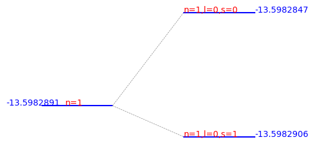

```python
import matplotlib
matplotlib.rcParams.update({'font.size':10})
plt.figure(figsize = (5,3), dpi = 100)
def plot_Ess(n):
    Z = 1; mu = (me*mp)/(me+mp)
    plt.hlines(bohr(Z,mu,n), 0, 0.3, color='blue')
    plt.text(-0.15,bohr(Z,mu,n),'%10.7f' % (bohr(Z,mu,n)),color='blue')
    plt.text(0.1, bohr(Z,mu,n), 'n='+str(n), color='red')
    for s in range(0, 2):
        plt.plot([0.3,0.6],[bohr(Z,mu,n),bohr(Z,mu,n)+Ess(n,s)], '--', color='gray', linewidth=0.5)
        plt.plot([0.6,0.9],[bohr(Z,mu,n)+Ess(n,s),bohr(Z,mu,n)+Ess(n,s)], color='blue')
        plt.text(0.9,bohr(Z,mu,n)+Ess(n,s),'%10.7f' % (bohr(Z,mu,n)+Ess(n,s)),color='blue')
        plt.text(0.6,bohr(Z,mu,n)+Ess(n,s),'n='+str(n)+',l='+str(0)+',s='+str(s),color='red')
    plt.axis('off'); plt.show()
plot_Ess(1)
```

# Exercícios

1. Para um campo escalar qualquer $\phi=\phi(\vec{r})$ e para um campo vetorial qualquer $\vec{A}=\vec{A}(\vec{r})$, verifique a igualdade \begin{equation} \vec{\nabla}\cdot\big(\phi\vec{A}\big) = \vec{\nabla}\phi\cdot\vec{A} + \phi\vec{\nabla}\cdot\vec{A}. \end{equation}
2. Considerando duas funções bem comportadas $f(\vec{r})$ e $g(\vec{r})$ e uma distribuição de corrente elétrica estacionária e localizada em um volume finito, demonstre a igualdade \begin{equation} \int_{V}\big(f\vec{J}\cdot\vec{\nabla}g+g\vec{J}\cdot\vec{\nabla}f\big)dV = 0. \end{equation}
3. Utilizando o resultado do último exercício, verifique que \begin{align} \vec{A}\cdot\int_{V}\vec{r}J_{i}dV & = -\frac{1}{2}\sum_{j}A_{j}\int_{V}\big(x_{j}J_{j}-x_{j}J_{i}\big)dV \\ & = -\frac{1}{2}\sum_{j,k}\epsilon_{ijk}A_{j}\int_{V}\big(\vec{r}\times\vec{J}\big)_{k}dV. \end{align}
4. Verifique a igualdade \begin{equation} \vec{\nabla}\times(\vec{A}\times\vec{B}) = (\vec{\nabla}\cdot\vec{B})\vec{A} - (\vec{\nabla}\cdot\vec{A})\vec{B} + (\vec{B}\cdot\vec{\nabla})\vec{A} - (\vec{A}\cdot\vec{\nabla})\vec{B}. \end{equation}
5. Verifique que \begin{equation} \vec{\nabla}\cdot\frac{\vec{r}}{r^{3}} = 4\pi\delta(\vec{r}). \end{equation}
6. Verifique que \begin{equation} (\vec{\mu}\cdot\vec{\nabla})\frac{\vec{r}}{r^{3}} = \frac{\vec{\mu}}{r^{3}} - 3\frac{(\vec{\mu}\cdot\vec{r})\vec{r}}{r^{5}}. \end{equation}
7. Para $\vec{\sigma}=\sum_{j=1}^{3}\hat{e}_{j}\sigma_{j}$, com \begin{equation} \sigma_{1} = \begin{bmatrix}0&1\\1&0\end{bmatrix},\ \sigma_{2} = \begin{bmatrix}0&-i\\i&0\end{bmatrix}, \ \sigma_{3} = \begin{bmatrix}1&0\\0&-1\end{bmatrix} \end{equation} e $\hat{r}$ um versor e $\{\hat{e}_{j}\}$ a base padrão de $\mathbb{R}^{3}$, verifique que \begin{equation} (\vec{\sigma}\cdot\hat{r})^{2}=\sigma_{0}, \end{equation} com $\sigma_{0}=\begin{bmatrix}1&0\\0&1\end{bmatrix}$.
8. Verifique que \begin{align} & \int_{0}^{\pi}\sin^{3}x dx = \frac{4}{3}, \\ & \int_{0}^{\pi}\sin x\cos^{2}x dx = \frac{2}{3}, \\ & \int_{0}^{2\pi}\sin^{2}x dx = \int_{0}^{2\pi}\cos^{2}x dx = \pi. \end{align}
9. Calcule as correções de 1ª ordem para a estrutura hiperfina do átomo de Hidrogênio para $n=2$ e $l=0$.
10. Calcule o comprimento de onda da radiação eletromagnética emitida em uma transição entre os estados hiperfinos do átomo de hidrogênio: $n=1,l=0,s=0\longrightarrow n=1,l=0,s=1$. Em qual faixa do espectro eletromagnético está este comprimento de onda?